# Breast Cancer Analysis

```r
dataR2 <- read_excel("dataR2.xlsx",
                     col_types = c("numeric", "numeric", "numeric",
                                   "numeric", "numeric", "numeric",
                                   "numeric", "numeric", "numeric", "text"))
dataR2[, ncol(dataR2)] <-sapply(dataR2[, ncol(dataR2)],as.numeric)
dataR2$Classification[dataR2$Classification == 1] <- 0
dataR2$Classification[dataR2$Classification == 2] <- 1
dataR2$Classification_label <- factor(dataR2$Classification, labels = c("control", "cancer"))

summary(dataR2$Classification_label)
```

```
## control  cancer
##      52      64
```

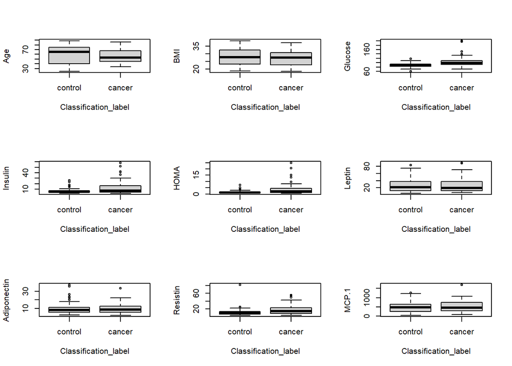

```r
par(mfrow=c(3,3))
boxplot(Age ~ Classification_label, data = dataR2)
boxplot(BMI ~ Classification_label, data = dataR2)
boxplot(Glucose ~ Classification_label, data = dataR2)
boxplot(Insulin ~ Classification_label, data = dataR2)
boxplot(HOMA ~ Classification_label, data = dataR2)
boxplot(Leptin ~ Classification_label, data = dataR2)
boxplot(Adiponectin ~ Classification_label, data = dataR2)
boxplot(Resistin ~ Classification_label, data = dataR2)
boxplot(MCP.1 ~ Classification_label, data = dataR2)
```

```r
#Age
summaryStats(dataR2$Age, dataR2$Classification_label)
```

```
##         Sample Size     Mean Median  Std Dev Midspread
## control          52 58.07692     65 18.95800     33.25
## cancer           64 56.67188     53 13.49315     23.00
```

```r
#BMI
summaryStats(dataR2$BMI, dataR2$Classification_label)
```

```
##         Sample Size     Mean   Median  Std Dev Midspread
## control          52 28.31734 27.69439 5.427465  9.232088
## cancer           64 26.98474 27.40803 4.620398  8.021347
```

```r
#Glucose
summaryStats(dataR2$Glucose, dataR2$Classification_label)
```

```
##         Sample Size      Mean Median  Std Dev Midspread
## control          52  88.23077   87.0 10.19153      10.5
## cancer           64 105.56250   98.5 26.55744      17.0
```

```r
#Insulin
summaryStats(dataR2$Insulin, dataR2$Classification_label)
```

```
##         Sample Size      Mean Median   Std Dev Midspread
## control          52  6.933769 5.4835  4.859793     2.697
## cancer           64 12.513219 7.5800 12.317738    11.657
```

```r
#HOMA
summaryStats(dataR2$HOMA, dataR2$Classification_label)
```

```
##         Sample Size     Mean   Median  Std Dev Midspread
## control          52 1.552398 1.139683 1.218256  0.895051
## cancer           64 3.623342 2.052256 4.588943  3.424470
```

```r
#Leptin
summaryStats(dataR2$Leptin, dataR2$Classification_label)
```

```
##         Sample Size     Mean   Median  Std Dev Midspread
## control          52 26.63793 21.49485 19.33470  24.87585
## cancer           64 26.59651 18.87765 19.21245  24.97537
```

```r
#Adiponectin
summaryStats(dataR2$Adiponectin, dataR2$Classification_label)
```

```
##         Sample Size     Mean   Median  Std Dev Midspread
## control          52 10.32821 8.127775 7.631281  5.365932
## cancer           64 10.06117 8.446438 6.189466  6.770622
```

```r
#Resistin
summaryStats(dataR2$Resistin, dataR2$Classification_label)
```

```
##         Sample Size     Mean   Median  Std Dev Midspread
## control          52 11.61481  8.92919 11.44705  6.211002
## cancer           64 17.25378 14.37182 12.63698 14.851495
```

```r
#MCP.1
summaryStats(dataR2$MCP.1, dataR2$Classification_label)
```

```
##         Sample Size     Mean   Median  Std Dev Midspread
## control          52 499.7307 471.3225 292.2422  382.1970
## cancer           64 563.0165 465.3740 384.0016  438.5743
```

# Initial Comments

The data set contains various clinical measurements from a sample of 116 women. Of those 116 women, 64 had breast cancer and 52 were healthy volunteers to act as a control group.

Looking at box plots there are some noticeable differences between the breast cancer group and the control group. The median age for the control group is 65 whereas the median age for the breast cancer group is 53. For Glucose, Insulin, HOMA and Resistin the spread is centered higher for the breast cancer group. A few of the plots show significant skewness and have outliers which will likely cause issues fitting the logistic model if ignored.

# Correlation Plot

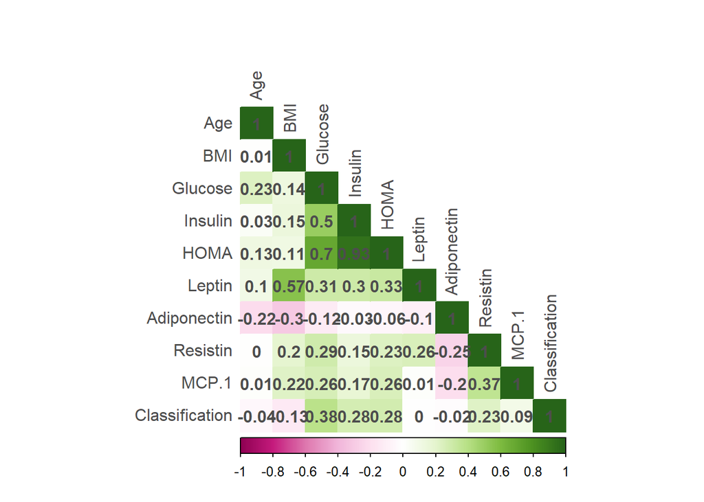

```r
par(mfrow=c(1,1))
corr_mat <- cor(dataR2[,1:10])
corrplot(corr_mat, method ="color", addCoef.col = 'grey30',col = COL2('PiYG'), tl.col = 'grey30',
         type = "lower", cl.ratio = 0.2)
```

Two of the covariate pairs have high correlations, HOMA & Insulin (r = 0.93) and HOMA & Glucose (r = 0.7). This an issue as one of the logistic regression assumptions is little/no multicollinearity among independent variables. The near zero correlations give us an indication of which variable pairs will not be of any use, as they will increase the degrees of freedom without contributing much to the model.

# Modelling Data

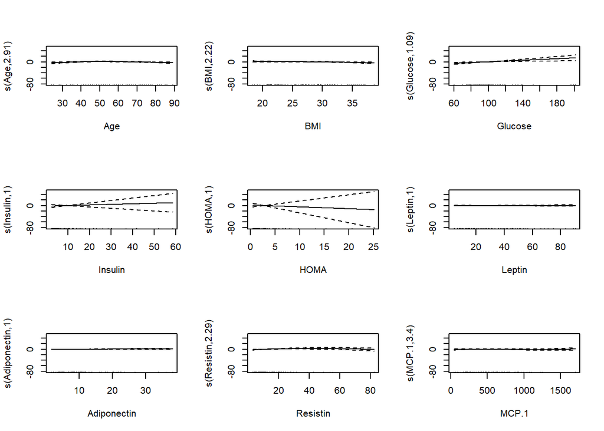

```r
#Fitting a GAM model
bc_gam_fit <- gam(Classification ~ s(Age) + s(BMI) + s(Glucose) +s(Insulin) + s(HOMA) + s(Leptin) +s(Adiponectin) + s(Resistin) +s(MCP.1), family = "binomial", data = dataR2)
par(mfrow=c(3,3))
plot(bc_gam_fit)
```

Firstly I used GAM plots to detect any non linear relationships. All variables look relatively linear, so we don’t need to fit any non linear terms. The linearity logistic regression assumption is also met.

```r
#Full model
bc_fit_1 <- glm(Classification ~ Age + BMI + log(Glucose) +log(Insulin)+ log(HOMA) + Leptin + log(Adiponectin)+log(Resistin) +MCP.1, family = binomial(link = "logit"), data = dataR2)


options(na.action = "na.fail")
all.fits <- dredge(bc_fit_1)
```

```
## Fixed term is "(Intercept)"
```

```r
head(all.fits)
```

```
## Global model call: glm(formula = Classification ~ Age + BMI + log(Glucose) + log(Insulin) +
##     log(HOMA) + Leptin + log(Adiponectin) + log(Resistin) + MCP.1,
##     family = binomial(link = "logit"), data = dataR2)
## ---
## Model selection table
##      (Int)      Age     BMI log(Glc) log(HOM) log(Ins) log(Rss) df  logLik
## 148 -42.78 -0.02296 -0.1574    9.965                      1.426  5 -55.657
## 147 -40.93          -0.1517    9.230                      1.436  4 -56.854
## 211 -38.66          -0.1742    8.624            0.5480    1.456  5 -55.814
## 179 -35.37          -0.1742    8.075   0.5479             1.456  5 -55.814
## 227  13.12          -0.1741            8.6180  -8.0700    1.455  5 -55.817
## 212 -40.55 -0.02163 -0.1787    9.364            0.5142    1.437  6 -54.793
##      AICc delta weight
## 148 121.9  0.00  0.191
## 147 122.1  0.21  0.172
## 211 122.2  0.31  0.163
## 179 122.2  0.31  0.163
## 227 122.2  0.32  0.163
## 212 122.4  0.50  0.149
## Models ranked by AICc(x)
```

Here I fit the full model and logged transformed some of the independent variables as they were noticeably skewed. Then I used the dredge function to determine the most suitable models, using AICc as the metric of comparison. I will use the first ranked model, my main criteria was to pick a high ranked model that did use either of the covariate pairs with high correlations as mentioned before. This model uses Age, BMI and logged Glucose and logged Resistin.

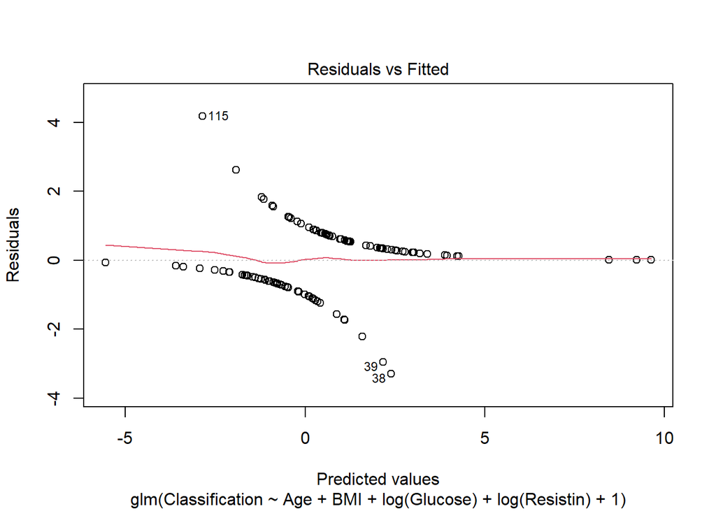

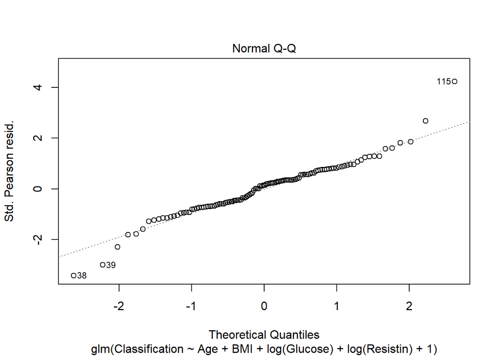

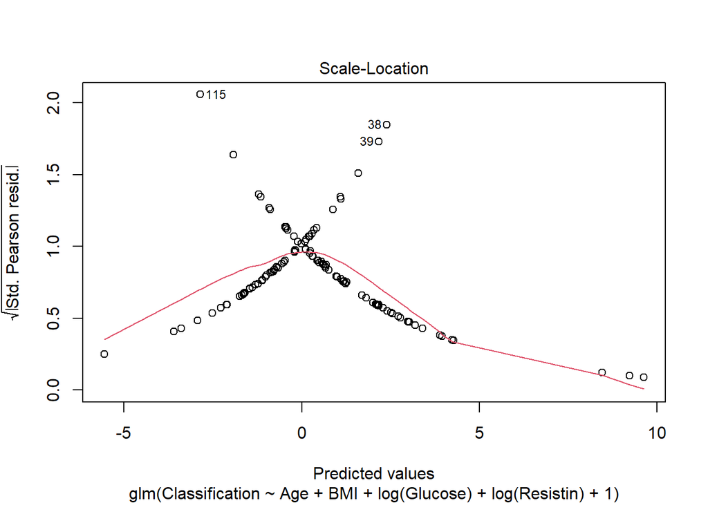

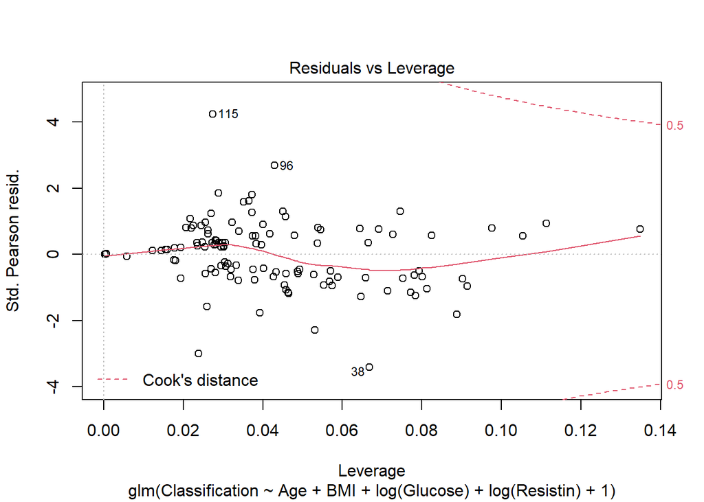

```r
par(mfrow=c(1,1))
bc_fit_top <-get.models(all.fits, 1)[[1]]
plot(bc_fit_top)
```

```r
summary(bc_fit_top)
```

```
##
## Call:
## glm(formula = Classification ~ Age + BMI + log(Glucose) + log(Resistin) +
##     1, family = binomial(link = "logit"), data = dataR2)
##
## Deviance Residuals:
##     Min       1Q   Median       3Q      Max
## -2.2251  -0.8055   0.1986   0.7963   2.4142
##
## Coefficients:
##                Estimate Std. Error z value Pr(>|z|)
## (Intercept)   -42.78036    9.61177  -4.451 8.55e-06 ***
## Age            -0.02296    0.01505  -1.526  0.12710
## BMI            -0.15739    0.04998  -3.149  0.00164 **
## log(Glucose)    9.96502    2.18060   4.570 4.88e-06 ***
## log(Resistin)   1.42596    0.44027   3.239  0.00120 **
## ---
## Signif. codes:  0 '***' 0.001 '**' 0.01 '*' 0.05 '.' 0.1 ' ' 1
##
## (Dispersion parameter for binomial family taken to be 1)
##
##     Null deviance: 159.57  on 115  degrees of freedom
## Residual deviance: 111.31  on 111  degrees of freedom
## AIC: 121.31
##
## Number of Fisher Scoring iterations: 5
```

```r
1-pchisq(deviance(bc_fit_top),df.residual(bc_fit_top))
```

```
## [1] 0.4737602
```

The p-value is 0.474, so we have no evidence to suggest a lack of fit.

```r
#Looking at effects
ggpredict(bc_fit_top,"Age [all]")
```

```
## # Predicted probabilities of Classification
##
## Age | Predicted |       95% CI
## ------------------------------
##  24 |      0.86 | [0.65, 0.95]
##  35 |      0.83 | [0.65, 0.93]
##  44 |      0.80 | [0.65, 0.89]
##  50 |      0.77 | [0.64, 0.87]
##  57 |      0.75 | [0.61, 0.85]
##  64 |      0.71 | [0.57, 0.82]
##  71 |      0.68 | [0.51, 0.81]
##  89 |      0.58 | [0.32, 0.80]
##
## Adjusted for:
## *      BMI = 27.58
## *  Glucose = 97.79
## * Resistin = 14.73
```

```r
ggpredict(bc_fit_top,"BMI [all]")
```

```
## # Predicted probabilities of Classification
##
##   BMI | Predicted |       95% CI
## --------------------------------
## 18.37 |      0.93 | [0.78, 0.98]
## 21.37 |      0.89 | [0.74, 0.95]
## 23.00 |      0.86 | [0.71, 0.93]
## 25.70 |      0.80 | [0.66, 0.89]
## 27.64 |      0.74 | [0.61, 0.84]
## 29.30 |      0.69 | [0.55, 0.80]
## 31.23 |      0.62 | [0.47, 0.75]
## 38.58 |      0.34 | [0.15, 0.60]
##
## Adjusted for:
## *      Age = 57.30
## *  Glucose = 97.79
## * Resistin = 14.73
```

```r
ggpredict(bc_fit_top,"Glucose [all]")
```

```
## # Predicted probabilities of Classification
##
## Glucose | Predicted |       95% CI
## ----------------------------------
##      60 |      0.02 | [0.00, 0.12]
##      78 |      0.23 | [0.12, 0.41]
##      85 |      0.42 | [0.29, 0.56]
##      91 |      0.59 | [0.46, 0.71]
##      98 |      0.75 | [0.61, 0.85]
##     104 |      0.84 | [0.71, 0.92]
##     114 |      0.93 | [0.81, 0.98]
##     201 |      1.00 | [0.99, 1.00]
##
## Adjusted for:
## *      Age = 57.30
## *      BMI = 27.58
## * Resistin = 14.73
```

```r
ggpredict(bc_fit_top,"Resistin [all]")
```

```
## # Predicted probabilities of Classification
##
## Resistin | Predicted |       95% CI
## -----------------------------------
##     3.21 |      0.25 | [0.10, 0.49]
##     4.82 |      0.37 | [0.21, 0.57]
##     6.89 |      0.50 | [0.35, 0.64]
##     8.89 |      0.59 | [0.46, 0.70]
##    10.70 |      0.65 | [0.52, 0.75]
##    13.97 |      0.73 | [0.60, 0.83]
##    17.56 |      0.79 | [0.64, 0.88]
##    82.10 |      0.97 | [0.83, 1.00]
##
## Adjusted for:
## *     Age = 57.30
## *     BMI = 27.58
## * Glucose = 97.79
```

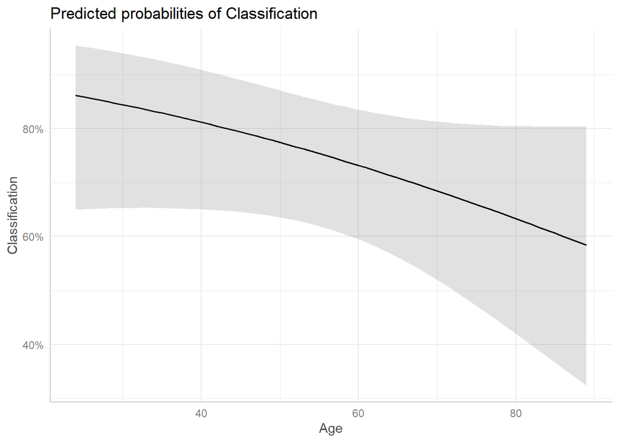

```r
plot(ggpredict(bc_fit_top,"Age [all]"))
```

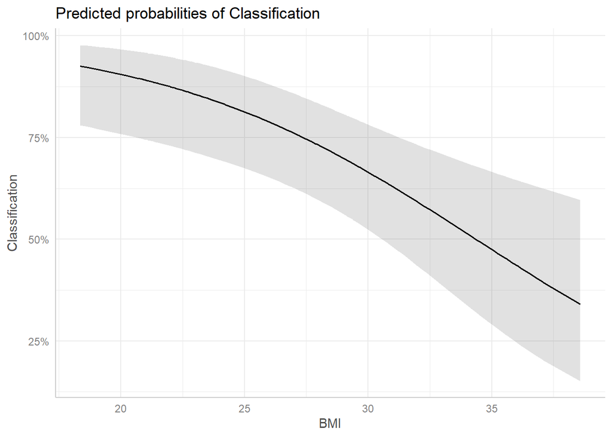

```r
plot(ggpredict(bc_fit_top,"BMI [all]"))
```

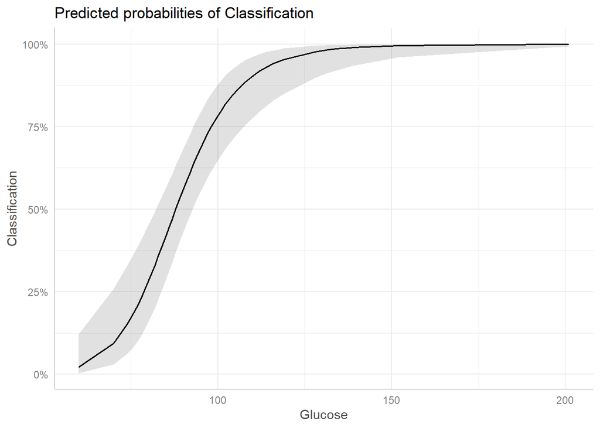

```r
plot(ggpredict(bc_fit_top,"Glucose [all]"))
```

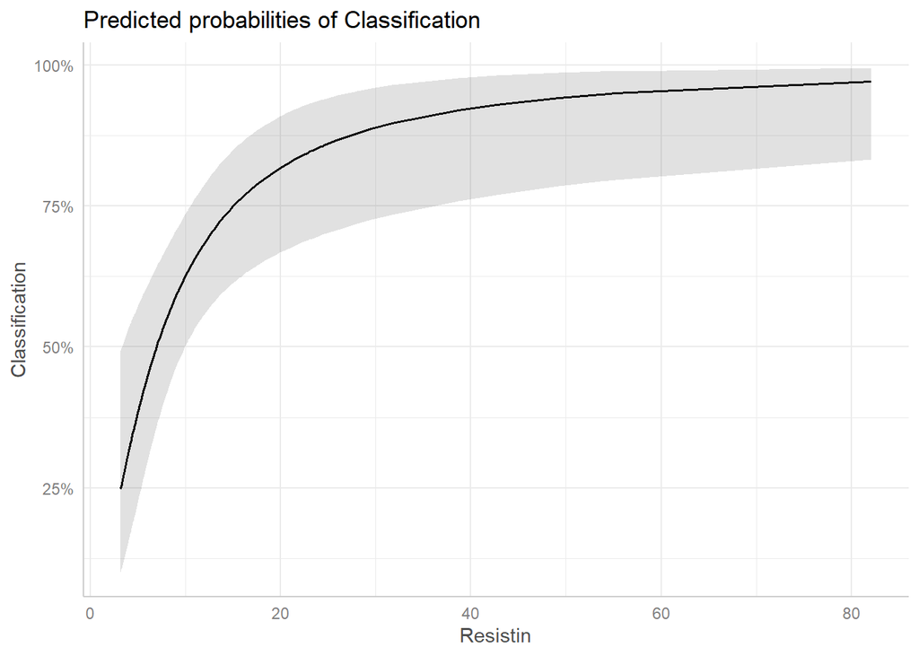

```r
plot(ggpredict(bc_fit_top,"Resistin [all]"))
```

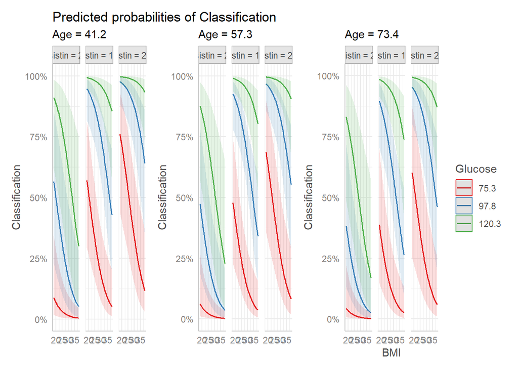

```r
#Marginal effects
plot(ggpredict(bc_fit_top,c("BMI [all]","Glucose","Resistin", "Age")))
```

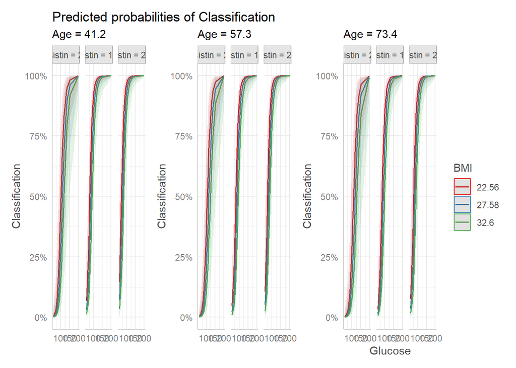

```r
plot(ggpredict(bc_fit_top,c("Glucose [all]","BMI","Resistin", "Age")))
```

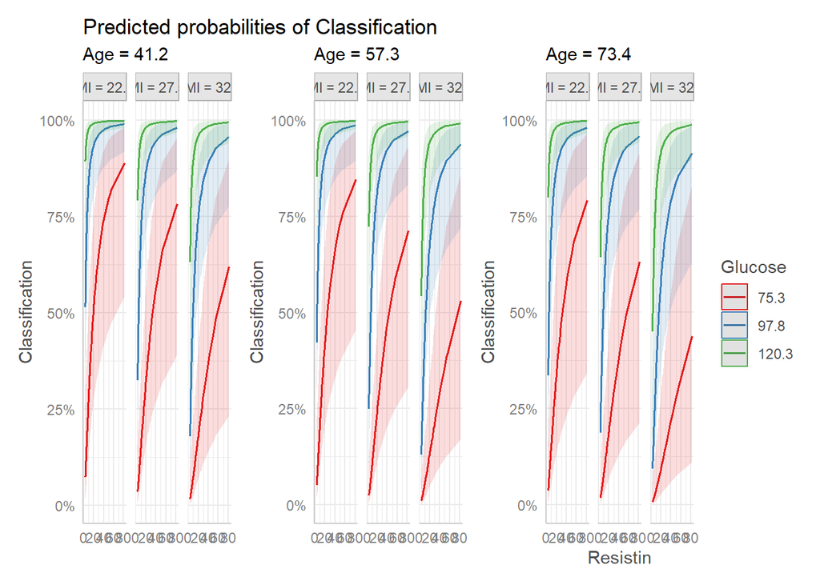

```r
plot(ggpredict(bc_fit_top,c("Resistin [all]","Glucose","BMI", "Age")))
```

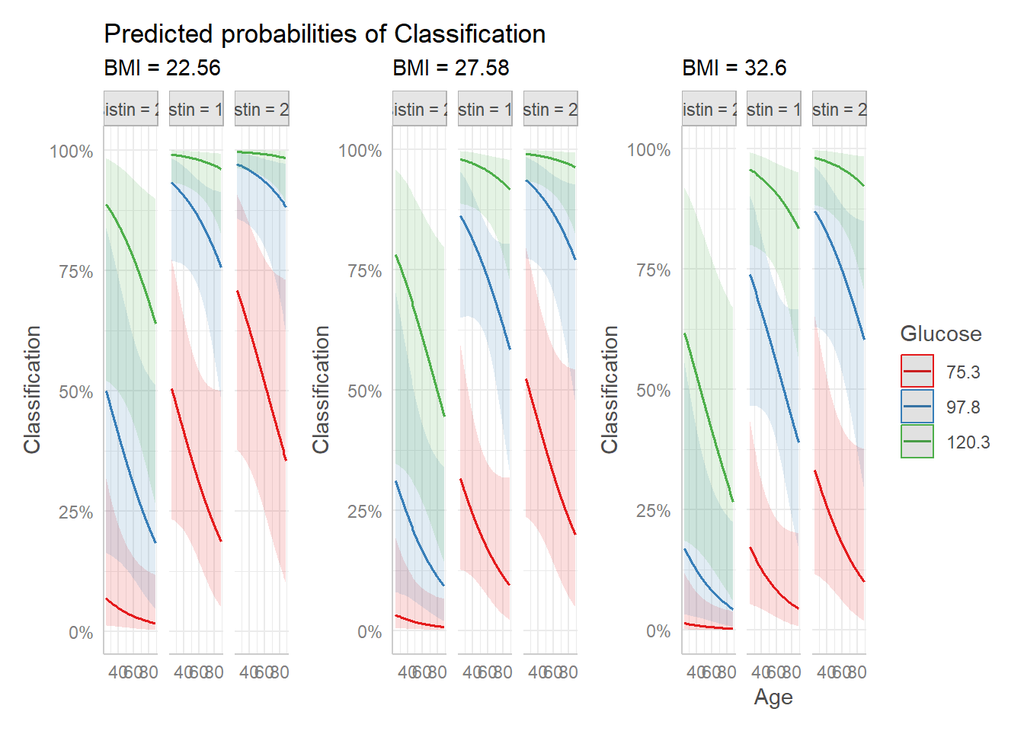

```r
plot(ggpredict(bc_fit_top,c("Age [all]","Glucose","Resistin", "BMI")))
```

```r
exp(confint(bc_fit_top))
```

```
##                      2.5 %       97.5 %
## (Intercept)   2.598512e-28 8.109102e-12
## Age           9.479794e-01 1.006093e+00
## BMI           7.702185e-01 9.384663e-01
## log(Glucose)  4.294003e+02 2.370733e+06
## log(Resistin) 1.862182e+00 1.060974e+01
```

```r
exp(coef(bc_fit_top))
```

```
##   (Intercept)           Age           BMI  log(Glucose) log(Resistin)
##  2.634670e-19  9.773049e-01  8.543712e-01  2.126921e+04  4.161867e+00
```

For every one year increase in age the odds of breast cancer are multiplied by 0.977 and for every one unit increase in BMI the odds of breast cancer are multiplied by 0.854. This is consistent with the decreasing trend in the Age and BMI plots. For every one unit increase in logged Glucose levels the odds of breast cancer are multiplied by 21269 and for every one unit increase in logged Resistin levels the odds of breast cancer are multiplied by 4.16. In general it looks like higher Glucose and Resistin levels are associated with higher odds of breast cancer. I was suprised to see that higher BMI appears to be associated with lower odds of having breast cancer.